# STA 601 Lab 1: R review

# Getting started

This course will assume that you have some familiarity with the R programming language. However, to refresh your memory on some R key topics, this lab will go through some basic aspects of R functionality that will be important for future exercises.

As a first step, recall how to install new R packages using the R console. One very useful package for working with data is the `tidyverse` package. Try installing it with

```r
install.packages("tidyverse")
```

Two other packages we will encounter in future labs are `rstan` and `rstanarm`. Install these with the command

```r
install.packages(c("rstan", "rstanarm"))
```

# Reading and writing files

Depending on who you collaborate with, you may receive data in different forms. These might include Excel (.xls), text files (.txt), comma-separated-value files (.csv), or R DAT files (.dat). One common function we use to load data into the environment is the read.table() function. The call might look like `read.table(file = "file name")`. The file name is fully determined by where the data is located on your device, and where your current working directory is.

Sometimes, we may be able to access data from a website. Let’s try to import data from Peter Hoff’s “A First Course in Bayesian Statistical Methods”:

```r
# for the entire help file for read.table(), type ?read.table into your console
data <- read.table(file = url("http://www2.stat.duke.edu/~pdh10/FCBS/Exercises/azdiabetes.dat"), header = T)
head(data)
```

```
##   npreg glu bp skin  bmi   ped age diabetes
## 1     5  86 68   28 30.2 0.364  24       No
## 2     7 195 70   33 25.1 0.163  55      Yes
## 3     5  77 82   41 35.8 0.156  35       No
## 4     0 165 76   43 47.9 0.259  26       No
## 5     0 107 60   25 26.4 0.133  23       No
## 6     5  97 76   27 35.6 0.378  52      Yes
```

### Exercise

# Objects

R utilizes objects called data structures, which include numeric vectors, matrices, lists, and data frames. If you are ever unsure about a variable’s type, you can run the command `str(<variable>)`.

We will frequently work with vectors and matrices. Vectors can be assigned using the `c()` function (the ‘c’ stands for ‘combine’). We can apply element-wise arithmetic to numeric vectors as follows. Make sure that you understand the following operations!

```r
# create numeric vector of length 5
num <- c(1,2,3,4,5)

#the following are equivalent:
num + 1
```

```
## [1] 2 3 4 5 6
```

```r
num + c(1,1,1,1,1)
```

```
## [1] 2 3 4 5 6
```

```r
num + c(1,1) # why does this throw an error?
```

```
## [1] 2 3 4 5 6
```

```r
# multiplication
num2 <- num*2
num2*c(0,0,1,1,1)
```

```
## [1]  0  0  6  8 10
```

```r
# power
num2^2
```

```
## [1]   4  16  36  64 100
```

Above, we created a numerical vector by listing out the elements 1,2,3,4,5. This works just fine if we only need a few elements. But what if we want all the integers between 1 and 100? We can use the `seq()` function to generate a numerical vector of values from the specified lower and upper bounds, at some regular interval:

```r
seq1 <- seq(from = 1, to = 100, by = 1) # the 'by' parameters determines the interval
seq1
```

```
##   [1]   1   2   3   4   5   6   7   8   9  10  11  12  13  14  15  16  17
##  [18]  18  19  20  21  22  23  24  25  26  27  28  29  30  31  32  33  34
##  [35]  35  36  37  38  39  40  41  42  43  44  45  46  47  48  49  50  51
##  [52]  52  53  54  55  56  57  58  59  60  61  62  63  64  65  66  67  68
##  [69]  69  70  71  72  73  74  75  76  77  78  79  80  81  82  83  84  85
##  [86]  86  87  88  89  90  91  92  93  94  95  96  97  98  99 100
```

### Exercise

Generate a sequence of $100$ equispaced real numbers from $0$ to $1$ and store it in a variable called `seq2`.

Let’s say we want to retrieve the i-th element in a vector. This is called indexing, and we do so using bracket notation. For example, if we want to retrieve the tenth element from seq1, then i=10:

```r
seq1[10]
```

```
## [1] 10
```

If we want the first and last elements, we can index the positions as follows:

```r
seq1[c(1,100)]
```

```
## [1]   1 100
```

If we want every element except the 25th and 50th, we can easily use the syntax:

```r
seq1[-c(25,50)]
```

```
##  [1]   1   2   3   4   5   6   7   8   9  10  11  12  13  14  15  16  17
## [18]  18  19  20  21  22  23  24  26  27  28  29  30  31  32  33  34  35
## [35]  36  37  38  39  40  41  42  43  44  45  46  47  48  49  51  52  53
## [52]  54  55  56  57  58  59  60  61  62  63  64  65  66  67  68  69  70
## [69]  71  72  73  74  75  76  77  78  79  80  81  82  83  84  85  86  87
## [86]  88  89  90  91  92  93  94  95  96  97  98  99 100
```

Suppose we don’t want the first element in seq1 to be 1, and would rather change it to 0. We can re-assign elements in numeric vectors by indexing the element we wish to re-assign, and specifying the replacement using `<-`:

```r
seq1[1] <- 0
seq1
```

```
##   [1]   0   2   3   4   5   6   7   8   9  10  11  12  13  14  15  16  17
##  [18]  18  19  20  21  22  23  24  25  26  27  28  29  30  31  32  33  34
##  [35]  35  36  37  38  39  40  41  42  43  44  45  46  47  48  49  50  51
##  [52]  52  53  54  55  56  57  58  59  60  61  62  63  64  65  66  67  68
##  [69]  69  70  71  72  73  74  75  76  77  78  79  80  81  82  83  84  85
##  [86]  86  87  88  89  90  91  92  93  94  95  96  97  98  99 100
```

There are many helpful functions which operate on numerical vectors. We can easily calculate the mean, standard deviation, variance, length, and much more! Below are just some examples of functions which you may find useful in this course and moving forward in your statistical career:

```r
seq3 <- seq(from = -3, to = 3, by = .5)
mean(seq3)
```

```
## [1] 0
```

```r
sd(seq3)
```

```
## [1] 1.94722
```

```r
var(seq3)
```

```
## [1] 3.791667
```

```r
length(seq3)
```

```
## [1] 13
```

```r
abs(seq3)
```

```
##  [1] 3.0 2.5 2.0 1.5 1.0 0.5 0.0 0.5 1.0 1.5 2.0 2.5 3.0
```

```r
exp(seq3)
```

```
##  [1]  0.04978707  0.08208500  0.13533528  0.22313016  0.36787944
##  [6]  0.60653066  1.00000000  1.64872127  2.71828183  4.48168907
## [11]  7.38905610 12.18249396 20.08553692
```

```r
sqrt(seq3)
```

```
##  [1]       NaN       NaN       NaN       NaN       NaN       NaN 0.0000000
##  [8] 0.7071068 1.0000000 1.2247449 1.4142136 1.5811388 1.7320508
```

```r
is.na(sqrt(seq3))
```

```
##  [1]  TRUE  TRUE  TRUE  TRUE  TRUE  TRUE FALSE FALSE FALSE FALSE FALSE
## [12] FALSE FALSE
```

### Exercise

Sort the entries in `seq3` from greatest to least.

# Matrices

In this course we will often utilize matrices, which are objects where every row/column is itself a numerical vector. To create a matrix, we use the function matrix() which takes in the data elements, number of columns and rows, and arrangement as arguments. We can then perform matrix arithmetic and operations, such as addition, multiplication, transpose, inverse. For example:

```r
mat1 <- matrix(data = seq(from = 1,to = 6, by =1), nrow = 3, ncol = 2, byrow = T)
mat2 <- matrix(data = rep(x = 2, times = 6), nrow = 3, ncol = 2)
mat3 <- mat1+mat2

#transpose of matrix: t()
t(mat3)
```

```
##      [,1] [,2] [,3]
## [1,]    3    5    7
## [2,]    4    6    8
```

```r
# matrix multiplication: %*%
# make sure dimensions agree!
dim(mat1); dim(mat2)
```

```
## [1] 3 2
```

```
## [1] 3 2
```

```r
mat1 %*% t(mat3)
```

```
##      [,1] [,2] [,3]
## [1,]   11   17   23
## [2,]   25   39   53
## [3,]   39   61   83
```

```r
# inverse (if non-singular): solve()
mat4 <- matrix(data = c(1,2,3,4), nrow = 2, ncol = 2, byrow = F)
solve(mat4)
```

```
##      [,1] [,2]
## [1,]   -2  1.5
## [2,]    1 -0.5
```

```r
# obtain elements of main diagonal: diag()
diag(mat4)
```

```
## [1] 1 4
```

```r
# create a diagonal matrix: diag(x, nrow, ncol). Default is x=1, which creates an identity matrix
diag(4) # creates 4x4 identity matrix
```

```
##      [,1] [,2] [,3] [,4]
## [1,]    1    0    0    0
## [2,]    0    1    0    0
## [3,]    0    0    1    0
## [4,]    0    0    0    1
```

```r
diag(x = 2, nrow = 4) # creates 4x4 diagonal matrix with 2 on diagonal
```

```
##      [,1] [,2] [,3] [,4]
## [1,]    2    0    0    0
## [2,]    0    2    0    0
## [3,]    0    0    2    0
## [4,]    0    0    0    2
```

Indexing matrices is similar to indexing vectors, but now that we are working in 2 dimensions, we need to specify the desired row and column. If we want the element in the i-th row and j-th column of mat4, then we use the syntax mat4[i,j]. If we want the entire i-th row, then we can leave the column index blank: mat4[i,] (and similarly for column).

```r
mat4[1,1]
```

```
## [1] 1
```

```r
mat4[,2]
```

```
## [1] 3 4
```

```r
mat4[,2] <- c(0,0)
mat4
```

```
##      [,1] [,2]
## [1,]    1    0
## [2,]    2    0
```

Lastly, suppose we have a large matrix and we wish to find the mean of every column. `apply()` is an extremely useful function which allows you to apply a specified function to an object, either row or column-wise. The function returns a vector or array of values:

```r
# generate large matrix
mat5 <- matrix(seq(1,100,1), nrow = 4, ncol = 25, byrow = T)

# apply(X = object, MARGIN = 1 for rows or 2 for columns, FUN = function of choice)
# find mean of every column
apply(X = mat5, MARGIN = 2, FUN = mean)
```

```
##  [1] 38.5 39.5 40.5 41.5 42.5 43.5 44.5 45.5 46.5 47.5 48.5 49.5 50.5 51.5
## [15] 52.5 53.5 54.5 55.5 56.5 57.5 58.5 59.5 60.5 61.5 62.5
```

### Exercise

Find the variance of each row of `mat5`

```r
# create a function to calculate log of maximum for arbitrary x, and returns the value stored in ret
log_max <- function(x) {
  ret <- log(max(x))
  return(ret)
}

# find log of maximum for each column
apply(X = mat5, MARGIN = 2, FUN = log_max)
```

```
##  [1] 4.330733 4.343805 4.356709 4.369448 4.382027 4.394449 4.406719
##  [8] 4.418841 4.430817 4.442651 4.454347 4.465908 4.477337 4.488636
## [15] 4.499810 4.510860 4.521789 4.532599 4.543295 4.553877 4.564348
## [22] 4.574711 4.584967 4.595120 4.605170
```

# Data frames

```r
str(data)
```

```
## 'data.frame':    532 obs. of  8 variables:
##  $ npreg   : int  5 7 5 0 0 5 3 1 3 2 ...
##  $ glu     : int  86 195 77 165 107 97 83 193 142 128 ...
##  $ bp      : int  68 70 82 76 60 76 58 50 80 78 ...
##  $ skin    : int  28 33 41 43 25 27 31 16 15 37 ...
##  $ bmi     : num  30.2 25.1 35.8 47.9 26.4 35.6 34.3 25.9 32.4 43.3 ...
##  $ ped     : num  0.364 0.163 0.156 0.259 0.133 ...
##  $ age     : int  24 55 35 26 23 52 25 24 63 31 ...
##  $ diabetes: Factor w/ 2 levels "No","Yes": 1 2 1 1 1 2 1 1 1 2 ...
```

You may be accustomed to extracting a column of data using the dollar sign operation. We can also use tidyverse language to access/manipulate data frames. However, what is returned from the `select()` function is not a numeric vector but another data frame:

```r
# Extract blood pressure from data
bp1 <- data$bp
str(bp1)
```

```
##  int [1:532] 68 70 82 76 60 76 58 50 80 78 ...
```

```r
# Select blood pressure from data
bp2 <- data %>% select(bp)
str(bp2)
```

```
## 'data.frame':    532 obs. of  1 variable:
##  $ bp: int  68 70 82 76 60 76 58 50 80 78 ...
```

In this course we will almost exclusively work with numerical data. Therefore, you may not need to foray into data frames. However, learning the tidyverse syntax can be very useful if you continue to work with R after this course.

# Random number generation and distribution functions

Many aspects of Bayesian inference – and therefore aspects of this course – involve simulating random variables from well-known families of distributions. These include the discrete Bernoulli, Poisson, and Binomial families, as well as the continuous Gaussian, Gamma, and Beta distributions.

You can obtain samples from these and other distributions using commands like:

```r
# Default is such that the first argument specifies the number of random samples you would like
X <- rnorm(10000, mean = 0, sd = sqrt(2))
Y <- rgamma(10000, shape = 1/2, rate = 1/2)
Z <- rpois(10000, lambda = 5)
```

You can also return the numerical values of the quantiles of these distributions (the inverse of the cumulative distribution function (CDF)) and their probability densities at desired values with slight variations to the base name of the distribution:

```r
std_norm_qt <- qnorm(0.95) # For what value x will the CDF function of a N(0,1) R.V. return 0.95?
std_norm_cdf <- pnorm(-2) # What is the value of the CDF function of a N(0,1) R.V. at -2?
std_norm_dens <- dnorm(0.5) # What is the value of the PDF function of a N(0,1) R.V. at 0.5?
```

### Exercise

Generate $500$ samples from a Beta distribution with shape parameter $[a, b] = [0.5, 0.5]$ and store the samples in a variable called `W`

# Plotting

When making plots in R, you have two main options: (1) the base R plotting function `plot` and (2) the package `ggplot2`.

The base R plotting functions are nice for quick, simple visualizations of data. Here are some examples:

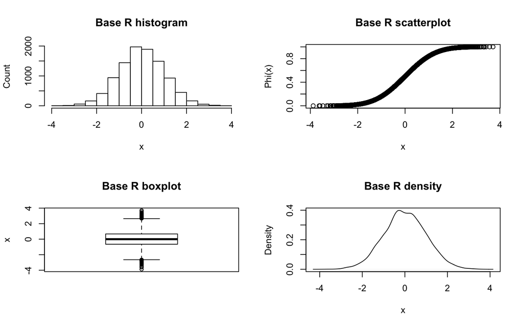

```r
norm_samples <- rnorm(10000)
#
par(mfrow = c(2, 2)) # Set the number of rows and columns for display panels
#
hist(norm_samples,
     main = "Base R histogram",
     xlab = "x", ylab = "Count")
#
plot(x = norm_samples, y = pnorm(norm_samples),
     main = "Base R scatterplot",
     xlab = "x", ylab = "Phi(x)")
#
boxplot(norm_samples,
        main = "Base R boxplot",
        ylab = "x")
#
plot(density(norm_samples),
     main = "Base R density",
     xlab = "x", ylab = "Density")
```

Plotting with `ggplot2` is generally a little bit easier when working with data in large tables. It has a gallery of built-in themes, and there are many extensions that make producing complicated visualizations relatively straightforward.

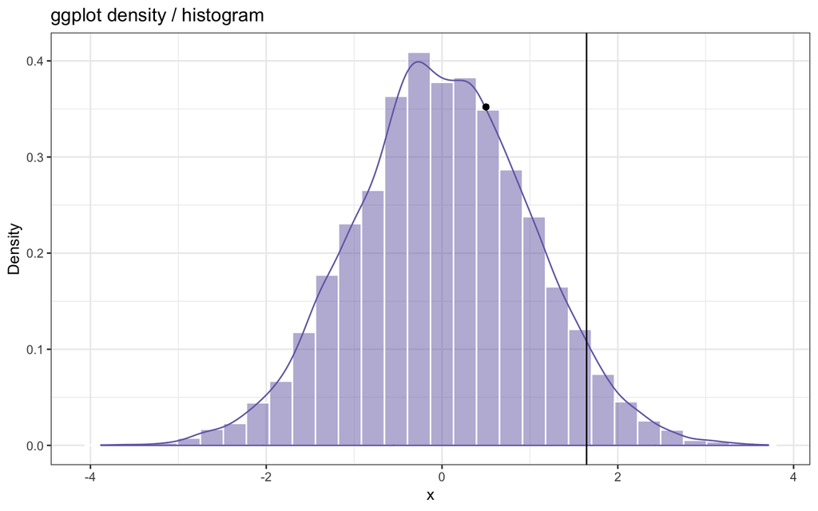

```r
norm_samples %>%
  data.frame(x = .) %>%
  ggplot2::ggplot() +
  geom_histogram(aes(x = x, y = ..density..),
                 fill = "#756bb1", colour = "white",
                 alpha = 0.5, bins = 30) +
  geom_density(aes(x = x), colour = "#756bb1") +
  geom_vline(aes(xintercept = std_norm_qt)) +
  geom_point(x = 0.5, y = std_norm_dens) +
  labs(x = "x", y = "Density", title = "ggplot density / histogram")
```

### Exercise

Browse online resources (some below), or use code from above to make a few plots of your own.

# R tutorials and resources

For more information on the R programming language please refer to some or all of the following resources:

- [R for Data Science](https://r4ds.had.co.nz)
- [ggplot2](https://ggplot2.tidyverse.org)
- [ColorBrewer](http://colorbrewer2.org)

STA 601: Bayesian Inference and Modern Statistical Methods

13 September, 2019